# Documentation 3. Descriptive Analysis

### STAT7008B Group 5

In this chapter we will find the frequency of the words used in the statements of netizens in each city on Weibo is mainly counted to observe their reactions to the epidemic and the frequency of the words used in policies.

```python
import pandas as pd
import re
import collections
import numpy as np
import jieba
import wordcloud
from PIL import Image
import matplotlib.pyplot as plt
import matplotlib
```

### Contents

- Words Frequancy and Word Clouds for Weibo in each City
- Words Frequancy and Word Clouds for Policies

# Words Frequancy and Word Clouds for Weibo in each City

## 1.1 Load Data

First we will load Weibo data for each cities, they are collected in excel file: "北京疫情-20220101-20220325.xls", "广州疫情-20220101-20220325.xls", "上海疫情-20220101-20220325.xls", "深圳疫情-20220101-20220325.xls".

```python
# Weibo
df_BJ_weibo = pd.read_excel("北京疫情-20220101-20220325.xls")
df_GZ_weibo = pd.read_excel("广州疫情-20220101-20220325.xls")
df_SH_weibo = pd.read_excel("上海疫情-20220101-20220325.xls")
df_SZ_weibo = pd.read_excel("深圳疫情-20220101-20220325.xls")
```

## 1.2 Data Preprocessing

Function data_clean() is used to delete the repeated weibo（which some are repeated because of unexpanded, called "未展开"）

```python
def data_clean(data_name): # 删除相同的微博（未展开）
    for i in range(data_name.shape[0]):
        weibo_day = data_name.loc[i].dropna()
        for j in range(len(weibo_day)-1):
            if weibo_day[j][:5] == weibo_day[j+1][:5]: # This judgement is to judge whether the weibo is repeated. As the weibo only
                                                       # repeat is adjacent, while the 1st one is unexpended and the 2nd one is what we
                                                       # need. We regard the first five words repeated as the same weibo.
                weibo_day[j] = np.nan   #set Nan to the previous unexpanded repeated weibo.
            data_name.loc[i] = weibo_day
    return data_name
```

### Using the function, we got processed data

‘df_BJ_weibo’ represent the Weibo after preprocessing for Beijing

‘df_GZ_weibo’ represent the Weibo after preprocessing for Guangzhou

‘df_SH_weibo’ represent the Weibo after preprocessing for Shanghai

‘df_SZ_weibo’ represent the Weibo after preprocessing for Shenzhen

```python
df_BJ_weibo = data_clean(df_BJ_weibo).set_index('date')
df_GZ_weibo = data_clean(df_GZ_weibo).set_index('date')
df_SH_weibo = data_clean(df_SH_weibo).set_index('date')
df_SZ_weibo = data_clean(df_SZ_weibo).set_index('date')
```

## 1.3 Create txt file

Function creat_txt is used to solve the text data from dataframe to txt file ( just easy to use in the following functions)

```python
citys = ['Beijing','Guangzhou','Shanghai','Shenzhen']

def creat_txt(city,weibo):
    f = open(city+"_微博.txt",'a') # creat a txt file for different city
    for i in range(len(weibo)): # go through all Weibo in each day
        daily_wb = weibo.iloc[i].dropna() # drop nan(the repeated Weibo we deleted before)
        for j in range(len(daily_wb)):
            sent_wb = daily_wb[j] # go through each Weibo in one day
            f.write(sent_wb) # save every Weibo into txt file
            f.write('\n')
    f.close() # close txt file
    return f
```

### Save the data (Weibo) into txt file

'Beijing_微博.txt' represent txt file to save the Weibo for Beijing 'Shanghai_微博.txt' represent txt file to save the Weibo for Shanghai 'Guangzhou_微博.txt' represent txt file to save the Weibo for Guangzhou 'Shenzhen_微博.txt' represent txt file to save the Weibo for Shenzhen

```python
creat_txt(citys[0],df_BJ_weibo)
creat_txt(citys[1],df_GZ_weibo)
creat_txt(citys[2],df_SH_weibo)
creat_txt(citys[3],df_SZ_weibo)
```

```
<_io.TextIOWrapper name='Shenzhen_微博.txt' mode='a' encoding='UTF-8'>
```

## 1.4 Draw Word Clouds (Function word_cloud)

```python
def word_cloud(data_file,image): # data_file: Weibo and policies text data
                                 # image: word clouds background
    fn = open(data_file) # open the txt file created before
    string_data = fn.read()
    fn.close()

    # Text pre-processing
    pattern = re.compile(u'\t|\n|\.|-|:|;|\)|\(|\?|"')
    string_data = re.sub(pattern, '', string_data)

    # Text Splitting
    StopWords = '停用词库.txt'  # dictionary of stop words
                               # for example: ['何','何况','何处','何时','作为','吱','呀','呃']
    seg_list_exact = jieba.lcut(string_data, cut_all = False) # use jieba doing Text Splitting
    object_list = []

    with open(StopWords, 'r') as meaninglessFile:
        stopwords = set(meaninglessFile.read().split('\n'))
    stopwords.add(' ')
    for word in seg_list_exact:
        if word not in stopwords:
            object_list.append(word)  # we do not want to calculate the stop words


    # Statistics on word frequency
    word_counts = collections.Counter(object_list) # Statistics on word frequency
    word_counts_top10 = word_counts.most_common(10) # top 10 most frequent words
    print (word_counts_top10)

    # draw bar plot for top 10 most frequent words
    word = []
    freq = []
    for l in word_counts_top10:
        word.append(l[0])
        freq.append(l[1])
    word.reverse() # just reverse let the plot show from most frequent to less frequent words
    freq.reverse()
    matplotlib.rc('font', family='Hiragino Sans GB', weight='bold', size=15) #family is used to show Chinese words
    plt.rcParams['axes.unicode_minus'] = False
    fig = plt.figure(figsize=(10,6))
    plt.title(data_file[:-7])
    plt.barh(word,freq)
    plt.show()

    # Word frequency display
    mask = np.array(Image.open(image)) # Define word frequency Background
    wc = wordcloud.WordCloud(
        background_color='black', # set the color of background
        font_path='/System/Library/Fonts/Hiragino Sans GB.ttc', # Set font format
        mask=mask, # Set background image
        max_words=200, # Maximum number of words displayed
        max_font_size=100 , # Font Max
        scale=32  # Adjust the picture clarity, the larger the value the clearer
    )

    wc.generate_from_frequencies(word_counts) # Generating word clouds from dictionaries
    image_colors = wordcloud.ImageColorGenerator(mask) # Create a color scheme from the background image
    wc.recolor(color_func=image_colors) # Set the word cloud color to the background image scheme
    wc.to_file(data_file[:-7]+"_微博.jpg") # Exporting images to files
    plt.imshow(wc) # Show word cloud
    plt.axis('off') # Close axis
    plt.show() # Display image
```

## 1.5 Results

### Beijing

```
[('北京', 29188), ('疫情', 28222), ('防控', 8598), ('核酸', 4980), ('病例', 4896), ('人员', 4848), ('冬奥会', 4704), ('检测', 4568), ('工作', 4324), ('确诊', 3624)]
```

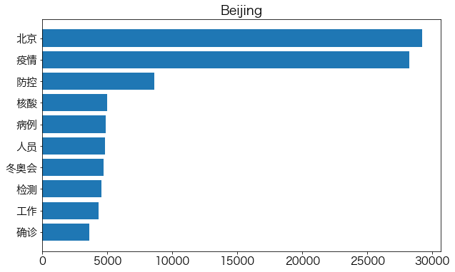

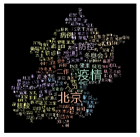

```python
word_cloud("Beijing_微博.txt","Beijing.JPG")
```

### Shanghai

```
[('上海', 25644), ('疫情', 23540), ('防控', 4654), ('核酸', 3172), ('高速', 2678), ('病例', 2674), ('人员', 2514), ('隔离', 2490), ('泪泪', 2406), ('工作', 2280)]
```

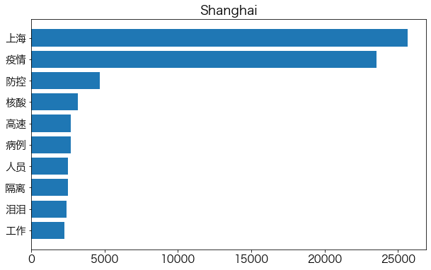

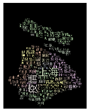

```python
word_cloud("Shanghai_微博.txt","Shanghai.JPG")
```

### Guangzhou

```
[('广州', 24526), ('疫情', 22782), ('核酸', 5906), ('防控', 5766), ('检测', 4172), ('深圳', 3266), ('人员', 3250), ('病例', 3130), ('新冠', 3112), ('广州市', 2896)]
```

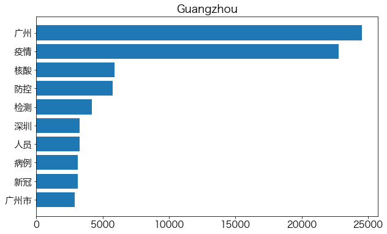

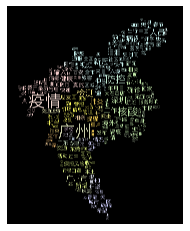

```python
word_cloud("Guangzhou_微博.txt","Guangzhou.JPG")
```

### Shenzhen

```
[('深圳', 31128), ('疫情', 26498), ('病例', 8190), ('核酸', 6320), ('防控', 5890), ('深圳市', 3370), ('检测', 3182), ('新增', 3156), ('隔离', 3114), ('确诊', 3096)]
```

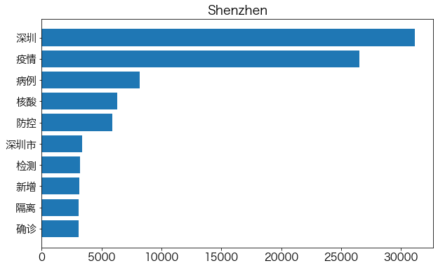

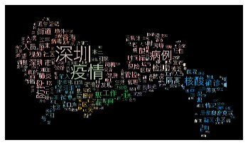

```python
word_cloud("Shenzhen_微博.txt","Shenzhen.JPG")
```

# Words Frequancy and Word Clouds for Policies

## 2.1 Load data and save it to txt file

Using the same way to save the text data from dataframe to txt file

```python
df_policies = pd.read_excel("Chinese government policies.xls")
speech = df_policies['Speech content']

f = open('全国政策.txt','a')
for i in range(len(speech)):
    speech_daily = speech[i]
    f.write(speech_daily)
    f.write('\n')
f.close()
```

## 2.2 Word Cloud and Frequency

Since the format of file name is different from Weibo, we just use the code in the word_cloud function to creat Frequency polt and Word Cloud for Chinese Policies.

### The code is exactly the same as in word_cloud function

```
[('疫情', 1988), ('防控', 1164), ('接种', 942), ('疫苗', 778), ('工作', 724), ('检测', 666), ('新冠', 540), ('做好', 458), ('核酸', 450), ('情况', 412)]
```

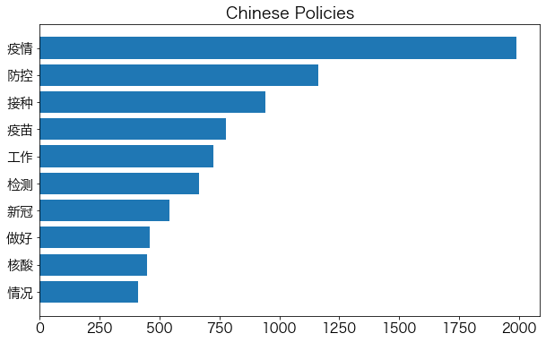

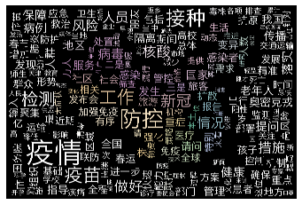

```python
fn = open('全国政策.txt')
string_data = fn.read()
fn.close()

# Text pre-processing
pattern = re.compile(u'\t|\n|\.|-|:|;|\)|\(|\?|"')
string_data = re.sub(pattern, '', string_data)

# Text Splitting
StopWords = '停用词库.txt'  # dictionary of stop words
seg_list_exact = jieba.lcut(string_data, cut_all = False)
object_list = []

with open(StopWords, 'r') as meaninglessFile:
    stopwords = set(meaninglessFile.read().split('\n'))
stopwords.add(' ')
for word in seg_list_exact:
    if word not in stopwords:
        object_list.append(word)    #we do not want to calculate the stop words

# Statistics on word frequency
word_counts = collections.Counter(object_list) # Statistics on word frequency
word_counts_top10 = word_counts.most_common(10) # top 10
print (word_counts_top10)

# draw bar plot for top 10 most frequent words
word = []
freq = []
for l in word_counts_top10:
    word.append(l[0])
    freq.append(l[1])
word.reverse()
freq.reverse()
matplotlib.rc('font', family='Hiragino Sans GB', weight='bold', size=15)
plt.rcParams['axes.unicode_minus'] = False
fig = plt.figure(figsize=(10,6))
plt.barh(word,freq)
plt.title('Chinese Policies')
plt.show()


# Word frequency display
mask = np.array(Image.open('中国.JPG'))
wc = wordcloud.WordCloud(
    background_color='black',
    font_path='/System/Library/Fonts/Hiragino Sans GB.ttc',
    mask=mask,
    max_words=200,
    max_font_size=100 ,
    scale=32
)

wc.generate_from_frequencies(word_counts)
image_colors = wordcloud.ImageColorGenerator(mask)
wc.recolor(color_func=image_colors)
wc.to_file("全国政策.jpg")
plt.imshow(wc)
plt.axis('off')
plt.show()
```